# 迴歸分析：要求 D、回應 R 與學業成就

心理統計學期末報告小組

2026-05-29

# 1 範圍與這份報告想回答什麼

1. 要求 D、回應 R 與學業成就的關聯，**方向、強度**是什麼？顯著嗎？兩者有沒有交互 作用？（§2–§3）
2. 把城鄉、公私立、偏遠、性別這些**結構背景**固定後，教養與學業的關聯還在嗎？到底是 這些背景在「移動 baseline」，還是它們「改變了教養的效果」？（§4–§5）
3. 整體解釋力由哪些變項堆出來、**教養占多少**？（§6）最後再用四類型的 ANOVA 與卡方 檢定把分析接回理論框架（§7）。

## 1.1 為什麼用連續迴歸，而不只是比較四類型的平均？

四類型把連續的 D、R 壓成高／低，雖然直觀，卻有代價：(1) **資訊損失**——`D_score` = 0 和 = 2 都算「低 D」，但兩者其實差很多；(2) **踩線者全歸低組**——中位數切分加「嚴格 大於」的機械效應（前一份報告已說明）；(3) 切分後再比平均，等於假設「同類學生彼此 同質」。連續迴歸直接用 D、R 原始分數、保留這些細節，因此本報告**以連續迴歸為主**， 四類型 ANOVA（§7）作為理論面的補充——兩者的 omnibus 結論其實一致（§7 會驗證）。

## 1.2 資料與模型設定

依變項為 `w2all3p`（綜合分析能力 IRT 分數）。樣本為重建後的 7280 名學生，剔除 `w2all3p` 遺漏 83 人後，迴歸樣本 **n = 7,197**。兩個設定：

- **D、R 置中**：分析用的 `D_c`、`R_c` 是把 `D_score`、`R_score` 減去**全體平均**。 為什麼要置中？因為含交互項時，未置中的 `D_c` 主效應只代表「R = 0 時的斜率」 （R = 0 在本樣本幾乎不存在、難以解讀），且 D 與 D×R 高度共線。置中後，主效應改讀為 「**對方在平均值時的斜率**」，截距改讀為「在平均 D、平均 R 時的預測成就」；各分層 共用同一置中基準，截距才能跨層比較。
- 分層用的四個變項：**城鄉**（鄉村／城鎮／都市）、**公私立**（公立／私立）、 **偏遠**（非偏遠／偏遠）、**性別**（男／女）。

# 2 全體迴歸：D + R 與 D × R

先看全體樣本。比較「加法模型」（`w2all3p ~ D + R`）與「交互模型」 （`w2all3p ~ D * R`）：

全體迴歸係數（*** p<.001, ** p<.01, * p<.05, . p<.10）

| 模型 | 項 | 係數 | 標準誤 | t | p 值 |
| --- | --- | --- | --- | --- | --- |
| D+R 加法模型 | (Intercept) | 0.9805 | 0.0135 | 72.54 | 0.00e+00*** |
| D+R 加法模型 | D_c | -0.1209 | 0.0107 | -11.28 | 2.88e-29*** |
| D+R 加法模型 | R_c | 0.0961 | 0.0118 | 8.17 | 3.55e-16*** |
| D*R 交互模型 | (Intercept) | 1.0104 | 0.0141 | 71.52 | 0.00e+00*** |
| D*R 交互模型 | D_c | -0.1138 | 0.0107 | -10.61 | 4.02e-26*** |
| D*R 交互模型 | R_c | 0.0982 | 0.0117 | 8.37 | 6.64e-17*** |
| D*R 交互模型 | D_c:R_c | -0.0540 | 0.0077 | -7.02 | 2.34e-12*** |

模型解釋力

| 模型 | R² | adj R² |
| --- | --- | --- |
| D+R 加法模型 | 0.0202 | 0.0200 |
| D*R 交互模型 | 0.0269 | 0.0265 |

**讀法**：

- **要求 D 的斜率為負**（-0.114***）—— 在回應 R 為平均時，要求每高 1 分，預測 `w2all3p` 約低 0.11。
- **回應 R 的斜率為正**（0.098***）—— 要求為平均時，回應每高 1 分，預測成就約高 0.10。
- **D × R 交互為負**（-0.054***）—— 在回應較高的家庭，過度要求對成就的負向關聯更明顯。
- 交互項顯著改善模型（巢狀 F 檢定：F = 49.3， p = 2.34e-12），故以**交互模型**為主。

模型解釋力 **adj R² 僅 2.7%**——很小。 這個數字本身的意義會在 §6、§8 與「常見疑問」討論（先講結論：R² 小不等於 D／R 不重要）；重點先放在**係數的方向與穩定性**。

## 2.1 穩健性：同一個模型套到三個成就指標

TEPS 測驗提供三個 3-PL（3 參數 IRT）能力估計值——**綜合**（`w2all3p`，本報告主分析）、 **數學**（`w2m3p`）、**一般分析**（`w2cf3p`）；三者高度相關 （r = 0.84–0.95， 綜合可視為數學與一般的合成）。把上面同一個交互模型 `成就 ~ D × R` 分別套到三個指標：

同一 D×R 交互模型套到三個成就指標的係數（*** p<.001, ** p<.01, * p<.05, . p<.10）

| 成就指標 | n | β_D（要求） | β_R（回應） | β_DR（交互） | adj R² |
| --- | --- | --- | --- | --- | --- |
| 綜合分析能力（主） | 7197 | -0.114*** | 0.098*** | -0.054*** | 0.0265 |
| 數學分析能力 | 7197 | -0.104*** | 0.088*** | -0.047*** | 0.0182 |
| 一般分析能力 | 7197 | -0.130*** | 0.100*** | -0.055*** | 0.0194 |

**讀法**：三個指標的 D、R、D×R 係數**方向完全一致**（要求 D 恆負、回應 R 恆正、交互 恆負），僅大小略有差異——教養與成就的關聯型態**不限於單一能力領域**，在數學與一般 推理上都成立。因綜合分析能力同時涵蓋兩者，§3–§7 的後續分析以它為主要結果。

光看係數有點抽象。下一節把（綜合分析能力的）交互模型預測值畫成熱圖，型態會更直觀。

# 3 迴歸預測熱圖

把交互模型的預測值畫在連續的 D × R 平面上（藍 = 預測成就高、紅 = 低；白線為等高線）：

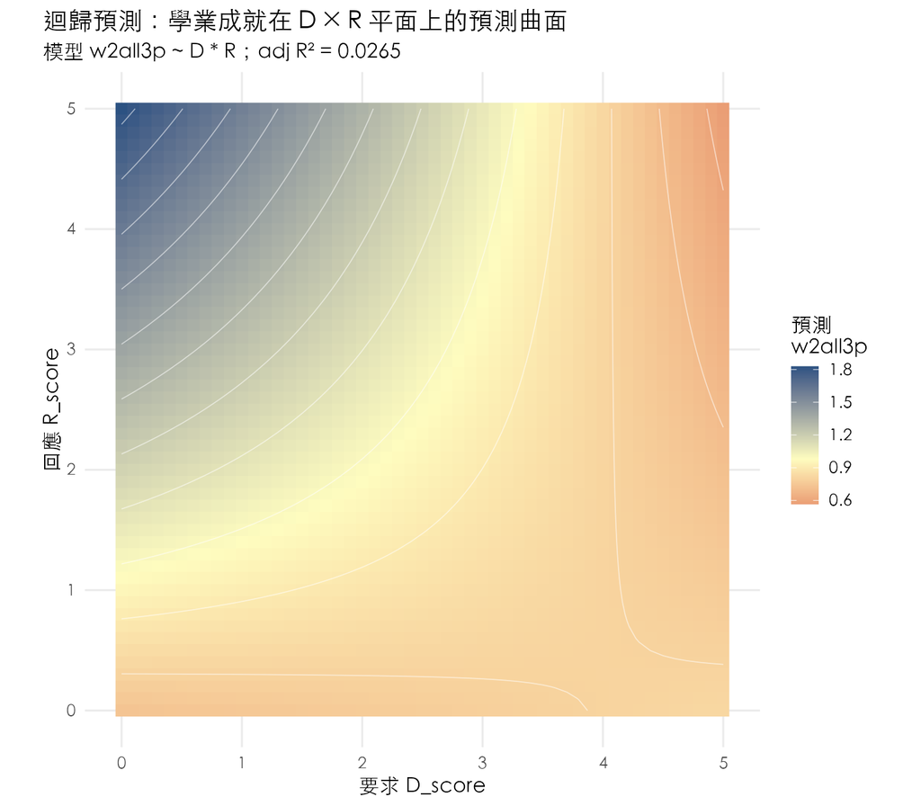

預測成就最高的區域在**低要求、高回應**一角（左上，深藍）；往右（要求變高）整體轉紅。 等高線並非直線而是彎曲的——這正是 D × R 負交互的呈現：在高回應一側（圖上方）， 等高線較密、要求 D 往右掉得較快，亦即**在高回應條件下，要求 D 與成就的負向關聯更明顯**。 這張「模型預測曲面」與描述性報告中「以實際資料平均」畫的熱圖型態一致，但更平滑、 可在 D×R 平面上呈現模型預測——兩種畫法呈現的型態方向一致。

到此為止分析的都是**全體樣本**。但學業成就顯然還受家庭與學校背景影響——下一節把這些 結構變項一個一個固定，看教養的關聯會不會跟著變。

# 4 分層迴歸：固定結構變項後的截距與斜率

「固定某個結構變項」的意思是：把樣本依該變項切成幾層（例如城鄉切成鄉村／城鎮／都市）， 在**每一層內各自**配適同一個交互模型，再把各層的截距與斜率擺在一起比。如果教養的效果 真的與背景無關，各層的斜率應該長得差不多。先看各層的係數表：

各分層內的迴歸係數（*** p<.001, ** p<.01, * p<.05, . p<.10）

| 分層變項 | 層級 | n | 截距 β₀ | β_D（要求） | β_R（回應） | β_DR（交互） | adj R² |
| --- | --- | --- | --- | --- | --- | --- | --- |
| 城鄉 | 鄉村 | 434 | 0.443 | -0.159*** | 0.198*** | -0.030 | 0.042 |
| 城鄉 | 城鎮 | 2,618 | 0.858 | -0.118*** | 0.085*** | -0.040** | 0.022 |
| 城鄉 | 都市 | 4,145 | 1.166 | -0.096*** | 0.085*** | -0.063*** | 0.026 |
| 公私立 | 公立 | 6,331 | 0.928 | -0.101*** | 0.093*** | -0.052*** | 0.023 |
| 公私立 | 私立 | 866 | 1.596 | -0.195*** | 0.048. | -0.022 | 0.062 |
| 偏遠 | 非偏遠 | 6,878 | 1.038 | -0.113*** | 0.095*** | -0.054*** | 0.026 |
| 偏遠 | 偏遠 | 319 | 0.378 | -0.119* | 0.113* | -0.005 | 0.014 |
| 性別 | 男 | 3,333 | 1.024 | -0.102*** | 0.099*** | -0.062*** | 0.024 |
| 性別 | 女 | 3,864 | 0.997 | -0.126*** | 0.098*** | -0.045*** | 0.029 |

**截距 β₀ 的差異很大**：城鄉從鄉村 0.44 到都市 1.17；公私立從公立 0.93 到私立 1.60；偏遠 0.38 遠低於非偏遠 1.04。也就是說，在平均 D、平均 R 的條件下， **學業成就的 baseline 強烈隨城鄉、公私立、偏遠移動**。唯一的例外是**性別**——男 1.02、女 1.00 的截距幾乎相同。

下圖把城鄉三層的迴歸預測曲面並排（共用色階）：整體偏藍／紅反映上述截距差異， 而**每個面內的梯度型態**（紅藍怎麼分布）反映該層的 D、R 斜率：

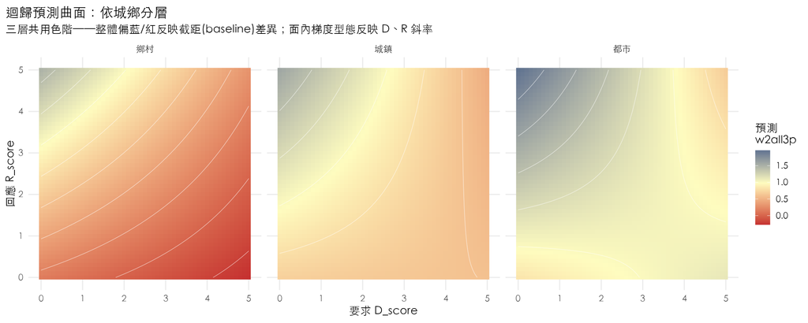

# 5 截距會變，那斜率呢？

這是本報告的核心問題：固定結構變項後，**D / R / D×R 的斜率有沒有跟著改變**， 還是只有截距在動？以巢狀 F 檢定正式檢定——

- **截距是否差**：比較 `D*R` 與 `D*R + 結構變項`（結構變項只移截距）。
- **斜率是否差**：比較 `D*R + 結構變項` 與 `D*R * 結構變項`（結構變項也調節 D/R 斜率）。

巢狀 F 檢定：截距差與斜率差

| 分層變項 | 截距差 F | 截距差 p | 斜率差 F | 斜率差 p | 判讀 |
| --- | --- | --- | --- | --- | --- |
| 城鄉 | 113.4 | 3.31e-49*** | 1.63 | 0.1340 | 只有截距移動、斜率不顯著改變 |
| 公私立 | 275.5 | 9.48e-61*** | 4.32 | 0.004780** | 截距移動、且斜率亦受調節 |
| 偏遠 | 92.2 | 1.08e-21*** | 0.74 | 0.5310 | 只有截距移動、斜率不顯著改變 |
| 性別 | 0.4 | 0.5360 | 0.86 | 0.4600 | 截距、斜率皆不顯著改變 |

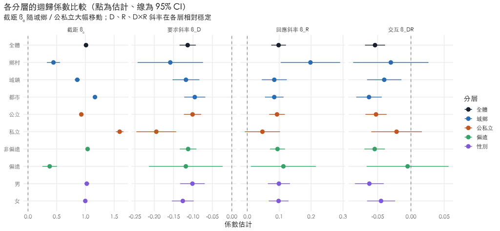

**結果**：

- **城鄉、公私立、偏遠都讓截距大幅移動**（截距差 p 全部 < .001）——baseline 學業成就 確實和這三個結構變項強烈相關。**性別則不然**：截距差 p = 0.54，男、女的 baseline 幾乎一樣。
- **城鄉、偏遠、性別：斜率差不顯著**（p = 0.13、 0.53、 0.46）——這些變項**不改變 D / R 斜率** （性別更是連截距都不移）。
- **公私立：斜率差顯著**（p = 0.004780）——私立學校的 要求斜率較陡（β_D = -0.19 vs 公立 -0.10），即私立生「高要求—低成就」的關聯更強。
- 但即使在公私立，**所有分層的 D、R、D×R 斜率方向完全一致**（要求恆負、回應恆正、 交互恆負），上面的係數比較圖也看得很清楚：截距 β₀ 那一欄左右散得很開、三個斜率欄 則各自聚成一束、沒有任何一層翻轉符號。

把這件事畫成最直觀的「**分層迴歸線**」——每個結構變項各畫一組迴歸線（要求 D 那列把 回應固定於平均、回應 R 那列把要求固定於平均）。**線平行＝該變項只移動截距；線扇開＝ 它調節了斜率**：

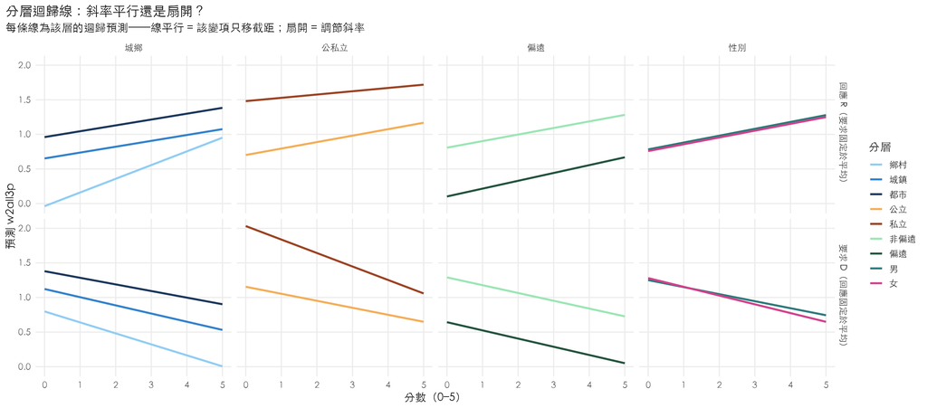

城鄉與偏遠各欄的線**接近平行**（只是高低不同）——印證「只移截距、不改變斜率」； **性別那欄兩條線幾乎完全重疊**——男、女的截距與斜率都幾乎相同。公私立的「要求 D」 那格，私立的線明顯比公立**陡**、兩條線扇開——這就是唯一一處顯著的斜率調節。而所有格子 裡每一條線，要求 D 一律向下、回應 R 一律向上，**沒有任何一條翻轉方向**。

# 6 解釋力從哪來：Forward stepwise

§5 用巢狀檢定談了「截距 vs 斜率」。這一節換個角度——**forward stepwise**：從空模型 開始，每一步加入「使 R² 增加最多」的變項，看整體解釋力是由哪些變項、各貢獻多少堆出來 的。候選為六個主效應（要求 D、回應 R、城鄉、公私立、偏遠、性別；交互 D×R 的貢獻見 §2）。

先看每個變項**單獨**能解釋多少 `w2all3p`：

各變項單獨對 w2all3p 的解釋力

| 變項 | 單獨 R² |
| --- | --- |
| 公私立 | 3.87% |
| 城鄉 | 3.26% |
| 偏遠 | 1.34% |
| 要求 D | 1.11% |
| 回應 R | 0.29% |
| 性別 | 0.00% |

再看 forward stepwise 的逐步路徑——每一步選「邊際 ΔR² 最大」者加入：

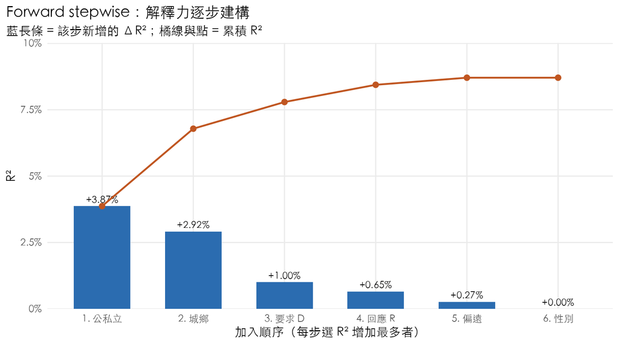

Forward stepwise 路徑

| 步驟 | 選入 | 本步 ΔR² | 累積 R² |
| --- | --- | --- | --- |
| 1 | 公私立 | +3.87% | 3.87% |
| 2 | 城鄉 | +2.92% | 6.79% |
| 3 | 要求 D | +1.00% | 7.79% |
| 4 | 回應 R | +0.65% | 8.44% |
| 5 | 偏遠 | +0.27% | 8.71% |
| 6 | 性別 | +0.00% | 8.71% |

**讀法**：

- **公私立 + 城鄉就占了最終解釋力的約 78%** （前兩步累積 6.79%、最終 8.71%）。 baseline 學業成就主要和學校屬性、城鄉位置綁在一起。
- **教養（要求 D + 回應 R）合計約 1.7 個百分點、約佔 19%**——比結構變項小一截，但**不是 0**。
- **偏遠**單獨能解釋 1.34%（比要求 D 還 高），在 stepwise 路徑卻排到第 5、只加 0.27%——因為偏遠地區高度與「城鄉、公立」 重疊，前兩步幾乎把它的解釋力吸光；D、R 則和結構變項較獨立，邊際貢獻反而留得住。
- **性別**幾乎不動 R²——與 §5「性別截距、斜率皆不顯著」一致。

這張全景**呼應、但不取代** §5：教養變項確實只占可解釋變異的一小塊（我們從不諱言）； 但 §5 已說明，教養的價值不在「占多少 R²」，而在它對學業成就的**關聯方向跨所有分層 穩定**。stepwise 量化了「大小」，§5 談的是「型態」——兩者一起才完整。

# 7 四類型：單因子 ANOVA 與卡方獨立性檢定（理論面的補充）

前面的連續迴歸用的是 D、R 原始分數。本節改用 Maccoby & Martin 的**四類型**——先做 單因子 ANOVA、再做卡方獨立性檢定——把分析接回研究的理論框架（四類型正是本研究的 核心概念）。

> **ANOVA 是迴歸的特例。** 對四類型做單因子 ANOVA，等同於以「類型」為因子的迴歸 `lm(w2all3p ~ Type)`——兩者的 omnibus F 完全相同（本報告實算 `aov` 與 `lm` 的 F 皆為 38.53）。所以本節不是「另一種方法」，而是「以具名類型呈現」 的同一套線性模型。**連續 D × R 迴歸仍是主要分析**（不依賴中位數切分、解釋力較高）； ANOVA 的價值在於回答連續迴歸不直接講的問題：**四個具名類型之間，誰和誰有差**。

四類型的學業成就平均：

| 教養類型 | n | w2all3p 平均 | SD |
| --- | --- | --- | --- |
| 開明權威 | 1,787 | 0.883 | 1.100 |
| 專制權威 | 1,550 | 0.855 | 1.094 |
| 寬鬆放任 | 1,245 | 1.280 | 1.165 |
| 忽視冷漠 | 2,615 | 0.978 | 1.206 |

單因子 ANOVA 顯示四類型的成就平均**確有差異**：F(3, 7,193) = 38.53，p = 1.07e-24。 但 omnibus F 只說「至少有兩類不同」；要知道**哪幾對**不同，需 Tukey 事後比較 （已對多重比較校正）：

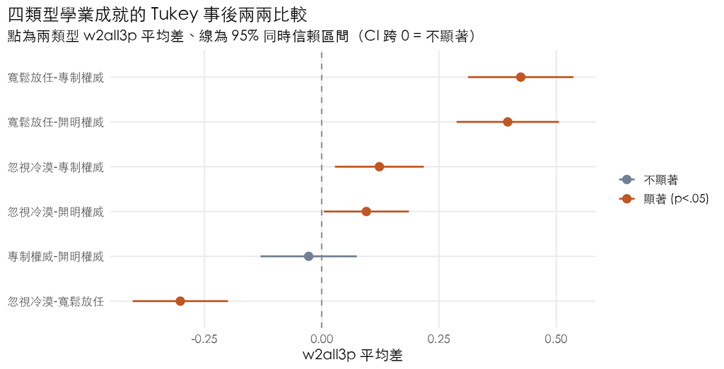

Tukey 事後兩兩比較（*** p<.001, ** p<.01, * p<.05）

| 類型對比 | 平均差 | 95% CI | p（校正） |
| --- | --- | --- | --- |
| 專制權威-開明權威 | -0.028 | [-0.130, 0.075] | 0.8990 |
| 寬鬆放任-開明權威 | 0.397 | [0.288, 0.506] | 7.82e-12*** |
| 忽視冷漠-開明權威 | 0.095 | [0.005, 0.186] | 0.03520* |
| 寬鬆放任-專制權威 | 0.424 | [0.312, 0.537] | 7.82e-12*** |
| 忽視冷漠-專制權威 | 0.123 | [0.028, 0.218] | 0.004720** |
| 忽視冷漠-寬鬆放任 | -0.301 | [-0.403, -0.200] | 7.98e-12*** |

**讀法**：六對比較中 5 對顯著、僅 1 對不顯著——

- **寬鬆放任顯著高於其他三類**（與開明 +0.40、與專制 +0.42、與忽視 +0.30，p 皆 < .001）。
- **忽視冷漠顯著高於開明、專制**（+0.10、+0.12，p = .035、.005）——差距小，但因樣本大 而顯著。
- **開明權威與專制權威之間沒有顯著差異**（差 −0.03，p = .90）——兩個「高要求」類型在 學業成就上幾乎相同。

成就排序因此是 **寬鬆放任 ≫ 忽視冷漠 >（開明權威 ≈ 專制權威）**。值得注意的是，西方 理論預期表現最佳的「開明權威」，在這個台灣樣本的成就平均與「專制權威」同為最低、 兩者差異並不顯著——這與 §3 連續迴歸「要求 D 斜率為負」一致：兩個高要求類型的成就 偏低。

## 7.1 類別版：教養類型 × 成就四分位的卡方獨立性檢定

§7 前半的 ANOVA 比的是四類型的成就**平均**。把同一個問題換成**類別**的問法——將 `w2all3p` 依四分位切成 Q1 低 ~ Q4 高四組，「教養類型」與「成就高低組」這兩個**類別 變項**是否**獨立**？這正是**卡方獨立性檢定**回答的問題，也讓本報告補齊三大課程方法 （迴歸、ANOVA、卡方）的最後一塊。檢定與本節 ANOVA 一致採未加權；4×4 列聯表每格 期望次數最小約 311，遠高於卡方檢定要求的 5，前提滿足。

下表為列聯表，括號內是**列百分比**（每個類型各自在四個四分位的人數佔比，每列加總 100%）：

教養類型 × 成就四分位列聯表：人數（列百分比）

| 教養類型 | Q1 低 | Q2 | Q3 | Q4 高 | n |
| --- | --- | --- | --- | --- | --- |
| 開明權威 | 479（26.8%） | 489（27.4%） | 470（26.3%） | 349（19.5%） | 1,787 |
| 專制權威 | 426（27.5%） | 429（27.7%） | 384（24.8%） | 311（20.1%） | 1,550 |
| 寬鬆放任 | 227（18.2%） | 246（19.8%） | 345（27.7%） | 427（34.3%） | 1,245 |
| 忽視冷漠 | 668（25.5%） | 635（24.3%） | 600（22.9%） | 712（27.2%） | 2,615 |

卡方獨立性檢定顯示，四類型與成就四分位**並非獨立**——χ²(9) = 146.0、p = 6.00e-27，兩者有顯著關聯。 但與本節前面的 Tukey 一樣要提醒：n = 7,197 很大，卡方 對微小偏離也會判為顯著，因此同時看效果量 Cramér’s V = 0.082——屬於 **小效果量**，關聯方向明確、強度卻不大。這與 §6「教養只占可解釋變異一小塊」的整體 圖像一致。

χ² 與 p 值是**整體檢定**——只回答「四類型與成就四分位整體上有沒有關聯」，不會告訴你 關聯**集中在哪幾格**。要把關聯定位到格子，就看**標準化殘差**；它可能有點久沒用了， 這裡先複習怎麼讀：

- **它在量什麼**：每一格先算出「若兩變項真的獨立、這格『應該』有多少人」（期望次數， ＝ 該列總數 × 該欄總數 ÷ 總人數）。標準化殘差就是把「實際人數 − 期望次數」這個差， 再除以它的標準誤、**標準化**成近似標準常態的值——目的是讓 16 個格子能用同一把尺比。
- **看正負**：殘差為**正**，代表該格實際人數**比期望多**；為**負**，代表**比期望少**。
- **看大小**：標準化後它近似標準常態，所以**殘差絕對值超過約 2**（嚴格的臨界值是 1.96）就代表這格明顯偏離「獨立」（約對應該格 p < .05）；絕對值越大、偏離越強。
- **它的角色**：標準化殘差是卡方版的「事後比較」，與本節 ANOVA 之後用 Tukey 找出 「哪幾對類型有差」用意相同——整體檢定說「有沒有關聯」，標準化殘差（或 Tukey）說 「關聯在哪裡」。但要注意：標準化殘差**未對 16 個格子做多重比較校正**（Tukey 則有 校正），因此這裡主要把它當作「把關聯定位到格子」的描述工具，而非嚴格的正式事後檢定。

下圖把 4×4 的標準化殘差畫成熱圖（藍 = 實際比期望多、紅 = 比期望少）：

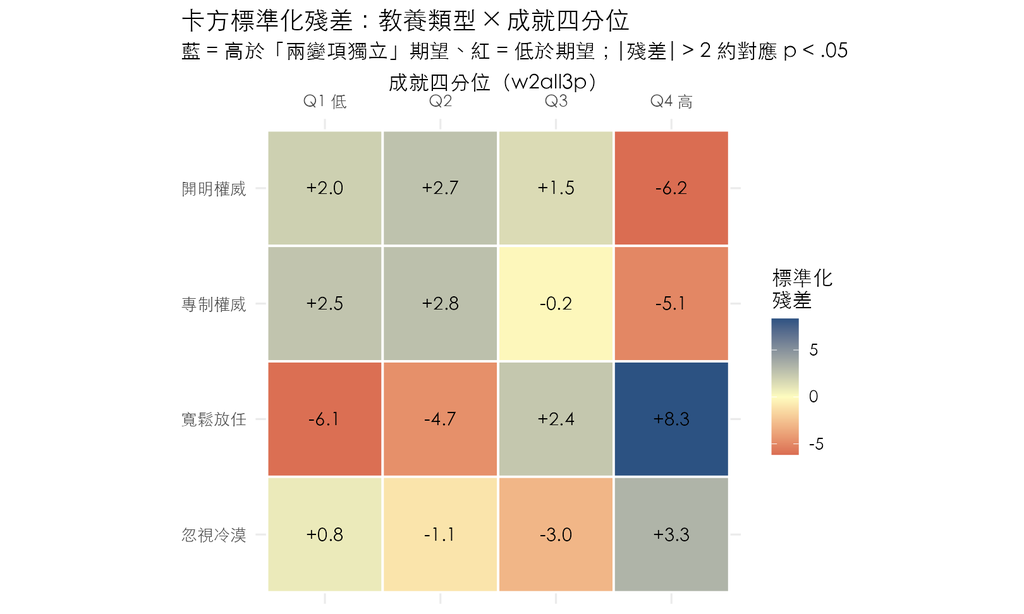

**讀法**（數字為上圖各格的標準化殘差）：

- **寬鬆放任明顯往高分端集中**：Q4 高的殘差高達 +8.3（全表最大），Q1 低、Q2 則為 -6.1、-4.7 （顯著偏少）。寬鬆放任有 34% 落在最高 四分位，遠高於「若兩變項獨立」應有的 25%。
- **兩個高要求類型（開明、專制）則明顯「缺席」最高四分位**：開明權威、專制權威在 Q4 高的殘差為 -6.2、 -5.1（皆顯著偏少），反而在 Q1 低、 Q2 偏多——落在 Q4 高的比例僅約 20%、 20%。
- **忽視冷漠**的型態相對平緩，僅 Q3 略少（-3.0）、 Q4 高略多（+3.3）。

這個型態與本節 ANOVA 的成就排序（寬鬆放任 ≫ 忽視冷漠 > 開明權威 ≈ 專制權威）完全 吻合：無論用「比平均」（ANOVA）或「比高低分組的人數分布」（卡方）來看，結論一致 ——低要求的寬鬆放任佔據高分端、兩個高要求類型被推往中低分端。卡方檢定不是另一個 故事，而是同一個型態的**類別版佐證**。一如全報告的立場，這裡只描述「關聯」，不宣稱 教養方式「造成」成就高低——反向因果與共同背景因素的可能，見 §8 的 Q2。

# 8 常見疑問

把分析做完後，幾個讀者（或助教）最可能追問的問題，在此一併回答：

**Q1：adj R² 只有 2.7%，這個分析 還有意義嗎？** 有。R² 小，代表學業成就的變異**大量來自本研究未納入的因素**（智力、家庭社經、學校 資源、個人努力……），這是社會科學橫斷資料的常態，不代表 D／R 與成就沒有關聯。本研究的 焦點不是「預測成就」，而是「教養與成就的**關聯型態**」——而這個型態（D 負、R 正、 交互負）在全體與**每一個結構分層**都一致、沒有任何一處翻轉，這種穩定性才是重點（§5）。 此外，「即使把這六個主效應候選變項（要求 D、回應 R、城鄉、公私立、偏遠、性別）全部 加總，也只解釋 8.7%」這件事本身，就是一個 值得報告的發現。

**Q2：「要求 D 與成就負相關」是不是代表「父母管越多、孩子越差」？** **不能這樣因果解讀。** 這個負向關聯至少有三種同樣合理的來源：(1) 反向因果——孩子 成績本來就較弱，父母因而加強要求；(2) 共同成因——某些家庭背景同時牽動教養與成就； (3) 題項內容——要求題偏「父母管不管」，本就可能與「需要被管的孩子」相關。本報告全程 只說「關聯」「方向」、不用「造成」「影響」，原因正在此。

**Q3：既然 ANOVA 是迴歸的特例，為什麼還要做 ANOVA（§7）？** 連續 D×R 迴歸回答「D、R 各自的斜率」，但不直接回答「四個**具名類型**之間誰和誰有差」。 §7 的單因子 ANOVA ＋ Tukey 事後比較正是補這一塊——它與 `lm(w2all3p ~ Type)` 的 omnibus F 完全相同，不是另一種方法，而是把同一套線性模型「以類型呈現」，讓分析接回 Maccoby & Martin 的理論語言。

**Q4：公私立顯著調節了要求斜率（§5），會不會推翻「教養效果穩定」的結論？** 不會。私立學校的要求斜率較陡（β_D 更負），但**方向仍是負的**、沒有翻轉成正。斜率 調節講的是「**程度**差異」（私立的負向關聯更強一些），不是「**方向**逆轉」。本研究 主張的「跨分層穩定」指的正是方向一致；公私立是程度上的唯一例外，幅度也不大。

# 9 小結

> 本報告為迴歸的描述與檢定，**未宣稱因果**。D 與成就的負向關聯也可能來自反向作用 （父母對成績較弱的孩子施加更多要求）或共同的背景因素，須謹慎解讀。

# 10 附錄：`regression.R` 完整程式碼

本報告於設定階段直接 `source()` 下列腳本後再計算正文數字與圖，因此報告與腳本必然一致。

```r
# =============================================================================
# Phase 4：迴歸分析（要求 D、回應 R → 學業成就 w2all3p）
# -----------------------------------------------------------------------------
# 讀 dr_scoring.R 產出的 analysis_data.rds。依變項 = w2all3p（綜合分析能力 IRT 分數），
# 以線性迴歸分析。
#
# 分析內容：
#   1. 全體模型：score ~ D + R（加法）、score ~ D * R（含交互）；交互模型另套到三個
#      成就指標（綜合 / 數學 / 一般分析）做穩健性對照。
#   2. 迴歸預測熱圖：由 D*R 模型在 D×R 平面上的預測曲面。
#   3. 分層迴歸：固定城鄉 / 公私立 / 偏遠後，比較各層的截距與 D、R、D×R 斜率，
#      並以巢狀 F 檢定正式檢定「截距是否差」與「斜率是否隨該變項改變」。
#
# D_c、R_c 為「全體平均置中」後的分數。置中後：交互模型的 D_c、R_c 主效應 =「對方在
# 平均值時的斜率」，截距 =「在平均 D、平均 R 時的預測成就」。各分層共用同一置中基準，
# 截距才能跨層比較。
#
# 註：本檔以「# ---- 英數標籤 ----」標記區段，與其他腳本一致。
# =============================================================================

# ---- setup ----
# 工作目錄須為專案根目錄（含 Data/ 與 教養分析/）：由報告 .Rmd 以 source()
# 呼叫時已設定好；單獨執行請先 setwd() 到專案根目錄。
library(ggplot2)
library(dplyr)
library(tidyr)

base    <- "教養分析"
out_dir <- file.path(base, "outputs", "regression")
fig_dir <- file.path(base, "outputs", "figures")
dir.create(out_dir, recursive = TRUE, showWarnings = FALSE)

font_family <- "Heiti TC"
png_device  <- if (requireNamespace("ragg", quietly = TRUE)) ragg::agg_png else "png"
theme_set(theme_minimal(base_size = 13, base_family = font_family) +
  theme(plot.title.position = "plot", panel.grid.minor = element_blank()))
save_plot <- function(p, file, w = 9, h = 5.5)
  ggsave(file.path(fig_dir, file), p, width = w, height = h, dpi = 180,
         device = png_device, bg = "white")

# ---- data ----
# 讀分析資料、剔除 w2all3p 遺漏者；置中 D、R；結構變項轉成有標籤的因子。
ana <- readRDS(file.path(base, "outputs", "dr_scoring", "analysis_data.rds"))$data
dat <- ana[!is.na(ana$w2all3p), ]
D_mean <- mean(dat$D_score)
R_mean <- mean(dat$R_score)
dat$D_c <- dat$D_score - D_mean
dat$R_c <- dat$R_score - R_mean
dat$urban <- factor(dat$w2urban3, levels = c(1, 2, 3),
                    labels = c("鄉村", "城鎮", "都市"))
dat$priv   <- factor(dat$w2priv, levels = c(0, 1), labels = c("公立", "私立"))
dat$far    <- factor(dat$w2far,  levels = c(0, 1), labels = c("非偏遠", "偏遠"))
dat$gender <- factor(dat$w2s445, levels = c(1, 2), labels = c("男", "女"))
achv_mean <- mean(dat$w2all3p)
N <- nrow(dat)

# ---- overall-models ----
# 全體：加法模型與交互模型。
M_add <- lm(w2all3p ~ D_c + R_c, data = dat)
M_int <- lm(w2all3p ~ D_c * R_c, data = dat)

coef_tab <- function(m, label) {
  s <- summary(m)$coefficients
  data.frame(模型 = label, 項 = rownames(s),
             估計 = s[, 1], 標準誤 = s[, 2], t = s[, 3], p = s[, 4],
             row.names = NULL)
}
overall_coef <- rbind(coef_tab(M_add, "D+R 加法模型"),
                      coef_tab(M_int, "D*R 交互模型"))
overall_fit <- data.frame(
  模型  = c("D+R 加法模型", "D*R 交互模型"),
  R2    = c(summary(M_add)$r.squared,     summary(M_int)$r.squared),
  adjR2 = c(summary(M_add)$adj.r.squared, summary(M_int)$adj.r.squared))
aov_int <- anova(M_add, M_int)   # 交互項是否顯著改善模型
write.csv(overall_coef, file.path(out_dir, "coef_overall.csv"),
          row.names = FALSE, fileEncoding = "UTF-8")
write.csv(overall_fit,  file.path(out_dir, "fit_overall.csv"),
          row.names = FALSE, fileEncoding = "UTF-8")

# ---- outcome-compare ----
# 穩健性：同一個 D*R 交互模型，分別套到三個 TEPS 成就指標（綜合 / 數學 / 一般分析）。
# 三者高度相關，看 D、R、D×R 的係數方向是否一致（教養型態是否不限單一能力領域）。
outcomes <- c(w2all3p = "綜合分析能力（主）",
              w2m3p   = "數學分析能力",
              w2cf3p  = "一般分析能力")
outcome_cor <- cor(sapply(dat[, names(outcomes)], as.numeric), use = "complete.obs")
outcome_compare <- do.call(rbind, lapply(names(outcomes), function(y) {
  m  <- lm(as.formula(paste(y, "~ D_c * R_c")), data = dat)
  co <- summary(m)$coefficients
  data.frame(指標 = outcomes[[y]], 變項 = y, n = nobs(m),
             beta_D = co["D_c", 1],      D_p  = co["D_c", 4],
             beta_R = co["R_c", 1],      R_p  = co["R_c", 4],
             beta_DR = co["D_c:R_c", 1], DR_p = co["D_c:R_c", 4],
             adjR2 = summary(m)$adj.r.squared, row.names = NULL)
}))
write.csv(outcome_compare, file.path(out_dir, "coef_by_outcome.csv"),
          row.names = FALSE, fileEncoding = "UTF-8")

# ---- regression-heatmap ----
# 由 D*R 交互模型，在 0–5 的 D×R 網格上預測學業成就，畫成預測曲面熱圖。
gv   <- seq(0, 5, 0.1)
grid <- expand.grid(D = gv, R = gv)
grid$D_c <- grid$D - D_mean
grid$R_c <- grid$R - R_mean
grid$pred <- predict(M_int, newdata = grid)
pA <- ggplot(grid, aes(D, R)) +
  geom_raster(aes(fill = pred)) +
  geom_contour(aes(z = pred), color = "white", alpha = 0.55, linewidth = 0.3) +
  scale_fill_gradient2(low = "#C53030", mid = "#FEFCBF", high = "#2C5282",
                       midpoint = achv_mean, name = "預測\nw2all3p") +
  coord_fixed() +
  scale_x_continuous(breaks = 0:5) + scale_y_continuous(breaks = 0:5) +
  labs(title = "迴歸預測：學業成就在 D × R 平面上的預測曲面",
       subtitle = sprintf("模型 w2all3p ~ D * R；adj R² = %.4f", summary(M_int)$adj.r.squared),
       x = "要求 D_score", y = "回應 R_score")
save_plot(pA, "07_regression_heatmap.png", 8, 7)

# ---- stratified-coef ----
# 固定結構變項，於各層內各自配適 D*R 模型，取出截距與 D、R、D×R 斜率。
strat_one <- function(svar, sname) {
  do.call(rbind, lapply(levels(dat[[svar]]), function(L) {
    sub <- dat[dat[[svar]] == L, ]
    co  <- summary(lm(w2all3p ~ D_c * R_c, data = sub))$coefficients
    data.frame(分層變項 = sname, 層級 = L, n = nrow(sub),
               截距 = co["(Intercept)", 1], 截距p = co["(Intercept)", 4],
               beta_D = co["D_c", 1],       D_p  = co["D_c", 4],
               beta_R = co["R_c", 1],       R_p  = co["R_c", 4],
               beta_DR = co["D_c:R_c", 1],  DR_p = co["D_c:R_c", 4],
               adjR2 = summary(lm(w2all3p ~ D_c * R_c, data = sub))$adj.r.squared,
               row.names = NULL)
  }))
}
strat_coef <- rbind(strat_one("urban",  "城鄉"),
                    strat_one("priv",   "公私立"),
                    strat_one("far",    "偏遠"),
                    strat_one("gender", "性別"))
write.csv(strat_coef, file.path(out_dir, "coef_stratified.csv"),
          row.names = FALSE, fileEncoding = "UTF-8")

# ---- slope-tests ----
# 巢狀 F 檢定。對每個結構變項 S：
#   截距是否差：比較 (D*R) vs (D*R + S)         —— S 是否使 baseline 移動。
#   斜率是否差：比較 (D*R + S) vs (D*R * S)     —— S 是否調節 D、R、D×R 斜率。
slope_test <- function(svar, sname) {
  mA <- lm(as.formula(sprintf("w2all3p ~ D_c * R_c + %s", svar)), data = dat)
  mB <- lm(as.formula(sprintf("w2all3p ~ D_c * R_c * %s", svar)), data = dat)
  a_int   <- anova(M_int, mA)
  a_slope <- anova(mA, mB)
  data.frame(分層變項 = sname,
             截距差_F = a_int$F[2],   截距差_p = a_int$`Pr(>F)`[2],
             斜率差_F = a_slope$F[2], 斜率差_p = a_slope$`Pr(>F)`[2])
}
slope_tests <- rbind(slope_test("urban",  "城鄉"),
                     slope_test("priv",   "公私立"),
                     slope_test("far",    "偏遠"),
                     slope_test("gender", "性別"))
write.csv(slope_tests, file.path(out_dir, "slope_tests.csv"),
          row.names = FALSE, fileEncoding = "UTF-8")
```

```r
# ---- fig-stratified-heatmap ----
# 依城鄉分層的迴歸預測曲面（三層共用色階）：整體偏藍 / 紅反映截距差；
# 面內梯度型態反映 D、R 斜率。
gridU <- do.call(rbind, lapply(levels(dat$urban), function(L) {
  m <- lm(w2all3p ~ D_c * R_c, data = dat[dat$urban == L, ])
  g <- expand.grid(D = gv, R = gv)
  g$D_c <- g$D - D_mean; g$R_c <- g$R - R_mean
  g$pred <- predict(m, newdata = g); g$urban <- L; g
}))
gridU$urban <- factor(gridU$urban, levels = c("鄉村", "城鎮", "都市"))
pB <- ggplot(gridU, aes(D, R)) +
  geom_raster(aes(fill = pred)) +
  geom_contour(aes(z = pred), color = "white", alpha = 0.55, linewidth = 0.3) +
  facet_wrap(~urban) +
  scale_fill_gradient2(low = "#C53030", mid = "#FEFCBF", high = "#2C5282",
                       midpoint = achv_mean, name = "預測\nw2all3p") +
  coord_fixed() +
  scale_x_continuous(breaks = 0:5) + scale_y_continuous(breaks = 0:5) +
  labs(title = "迴歸預測曲面：依城鄉分層",
       subtitle = "三層共用色階——整體偏藍/紅反映截距(baseline)差異；面內梯度型態反映 D、R 斜率",
       x = "要求 D_score", y = "回應 R_score")
save_plot(pB, "08_regression_heatmap_by_urban.png", 13, 5.2)

# ---- fig-coef-compare ----
# 各分層的迴歸係數（截距、D、R、D×R 斜率）+ 95% CI，並排比較。
collect <- function(m, label, group) {
  ci <- confint(m); co <- summary(m)$coefficients
  tm <- c("(Intercept)", "D_c", "R_c", "D_c:R_c")
  data.frame(model = label, group = group, term = tm,
             est = co[tm, 1], lo = ci[tm, 1], hi = ci[tm, 2], row.names = NULL)
}
per_level <- function(svar, group) do.call(rbind, lapply(levels(dat[[svar]]),
  function(L) collect(lm(w2all3p ~ D_c * R_c, data = dat[dat[[svar]] == L, ]), L, group)))
cc <- rbind(collect(M_int, "全體", "全體"),
            per_level("urban",  "城鄉"),
            per_level("priv",   "公私立"),
            per_level("far",    "偏遠"),
            per_level("gender", "性別"))
cc$term  <- factor(cc$term, levels = c("(Intercept)", "D_c", "R_c", "D_c:R_c"),
                   labels = c("截距 β₀", "要求斜率 β_D", "回應斜率 β_R", "交互 β_DR"))
cc$model <- factor(cc$model, levels = rev(c("全體", "鄉村", "城鎮", "都市",
                                            "公立", "私立", "非偏遠", "偏遠",
                                            "男", "女")))
cc$group <- factor(cc$group, levels = c("全體", "城鄉", "公私立", "偏遠", "性別"))
pC <- ggplot(cc, aes(est, model, color = group)) +
  geom_vline(xintercept = 0, linetype = "dashed", color = "grey55") +
  geom_pointrange(aes(xmin = lo, xmax = hi), linewidth = 0.6) +
  facet_wrap(~term, scales = "free_x", nrow = 1) +
  scale_color_manual(values = c("全體" = "#1A202C", "城鄉" = "#2B6CB0",
                                "公私立" = "#C05621", "偏遠" = "#38A169",
                                "性別" = "#805AD5"),
                     name = "分層") +
  labs(title = "各分層的迴歸係數比較（點為估計、線為 95% CI）",
       subtitle = "截距 β₀ 隨城鄉 / 公私立大幅移動；D、R、D×R 斜率在各層相對穩定",
       x = "係數估計", y = NULL)
save_plot(pC, "09_coef_comparison.png", 13, 6)

# ---- fig-slope-lines ----
# 圖 10：分層迴歸線——把每個結構變項拆開、各層各畫一條迴歸線。
#   「要求 D」列：回應 R 固定於平均；「回應 R」列：要求 D 固定於平均。
#   線平行 = 該變項只移截距、不調節斜率；線扇開 = 調節斜率。
make_lines <- function(svar, sname) {
  do.call(rbind, lapply(levels(dat[[svar]]), function(L) {
    m <- lm(w2all3p ~ D_c * R_c, data = dat[dat[[svar]] == L, ])
    rbind(
      data.frame(structural = sname, level = L,
                 predictor = "要求 D（回應固定於平均）", x = gv,
                 pred = predict(m, data.frame(D_c = gv - D_mean, R_c = 0))),
      data.frame(structural = sname, level = L,
                 predictor = "回應 R（要求固定於平均）", x = gv,
                 pred = predict(m, data.frame(D_c = 0, R_c = gv - R_mean))))
  }))
}
lines_df <- rbind(make_lines("urban",  "城鄉"),
                  make_lines("priv",   "公私立"),
                  make_lines("far",    "偏遠"),
                  make_lines("gender", "性別"))
lines_df$structural <- factor(lines_df$structural,
  levels = c("城鄉", "公私立", "偏遠", "性別"))
lines_df$level <- factor(lines_df$level,
  levels = c("鄉村", "城鎮", "都市", "公立", "私立", "非偏遠", "偏遠", "男", "女"))
line_cols <- c("鄉村" = "#90CDF4", "城鎮" = "#3182CE", "都市" = "#1A365D",
               "公立" = "#F6AD55", "私立" = "#9C4221",
               "非偏遠" = "#9AE6B4", "偏遠" = "#22543D",
               "男" = "#2C7A7B", "女" = "#D53F8C")
pD <- ggplot(lines_df, aes(x, pred, color = level)) +
  geom_line(linewidth = 1.1) +
  facet_grid(predictor ~ structural) +
  scale_color_manual(values = line_cols, name = "分層") +
  labs(title = "分層迴歸線：斜率平行還是扇開？",
       subtitle = "每條線為該層的迴歸預測——線平行 = 該變項只移截距；扇開 = 調節斜率",
       x = "分數（0–5）", y = "預測 w2all3p") +
  theme(legend.position = "right")
save_plot(pD, "10_slopes_by_group.png", 15, 6.6)

# ---- anova-typology ----
# 四類型單因子 ANOVA + Tukey 事後比較（面向理論的補充分析）。
# ANOVA 是迴歸的特例：aov(w2all3p ~ Type) 的 omnibus F 等於 lm(w2all3p ~ Type)。
aov_type <- aov(w2all3p ~ Type, data = dat)
aov_tab  <- summary(aov_type)[[1]]
lm_type  <- lm(w2all3p ~ Type, data = dat)          # 對照組：與 aov 為同一模型
tuk <- as.data.frame(TukeyHSD(aov_type)$Type)
names(tuk) <- c("diff", "lwr", "upr", "p_adj")
tuk$pair <- rownames(tuk)
tm <- aggregate(w2all3p ~ Type, dat,
                function(x) c(n = length(x), mean = mean(x), sd = sd(x)))
type_means <- data.frame(Type = tm$Type, n = tm$w2all3p[, "n"],
                         mean = tm$w2all3p[, "mean"], sd = tm$w2all3p[, "sd"])
write.csv(tuk[, c("pair", "diff", "lwr", "upr", "p_adj")],
          file.path(out_dir, "anova_tukey.csv"), row.names = FALSE, fileEncoding = "UTF-8")
write.csv(type_means, file.path(out_dir, "anova_type_means.csv"),
          row.names = FALSE, fileEncoding = "UTF-8")

# 圖 11：Tukey 六對兩兩比較（平均差 ± 95% 同時信賴區間）。
tuk$sig      <- ifelse(tuk$p_adj < .05, "顯著 (p<.05)", "不顯著")
tuk$pair_lab <- factor(tuk$pair, levels = tuk$pair[order(tuk$diff)])
pE <- ggplot(tuk, aes(diff, pair_lab, color = sig)) +
  geom_vline(xintercept = 0, linetype = "dashed", color = "grey55") +
  geom_pointrange(aes(xmin = lwr, xmax = upr), linewidth = 0.8) +
  scale_color_manual(values = c("顯著 (p<.05)" = "#C05621", "不顯著" = "#718096"),
                     name = NULL) +
  labs(title = "四類型學業成就的 Tukey 事後兩兩比較",
       subtitle = "點為兩類型 w2all3p 平均差、線為 95% 同時信賴區間（CI 跨 0 = 不顯著）",
       x = "w2all3p 平均差", y = NULL)
save_plot(pE, "11_tukey_pairs.png", 9, 4.6)
```

```r
# ---- chisq-typology ----
# 四類型 × 成就四分位的卡方獨立性檢定（理論面補充的「類別版」，與上方 ANOVA 對照）。
# ANOVA 比四類型的成就「平均」；卡方檢定「教養類型」與「成就高低類別」這兩個類別變項
# 是否獨立。與本節 ANOVA 一致採未加權；w2all3p 依四分位切成 Q1 低 ~ Q4 高四組。
qb <- quantile(dat$w2all3p, probs = 0:4 / 4)
dat$achv_q <- cut(dat$w2all3p, breaks = qb, include.lowest = TRUE,
                  labels = c("Q1 低", "Q2", "Q3", "Q4 高"))
chi_tab  <- table(教養類型 = dat$Type, 成就四分位 = dat$achv_q)  # 4×4 次數列聯表
chi_test <- chisq.test(chi_tab)                                   # Pearson 卡方獨立性檢定
# Cramér's V：卡方的效果量（n 大時卡方對微小偏離也會顯著，用 V 表關聯「強度」）。
chi_V <- sqrt(as.numeric(chi_test$statistic) /
              (sum(chi_tab) * (min(dim(chi_tab)) - 1)))
chi_rowpct <- prop.table(chi_tab, margin = 1) * 100               # 列百分比（每列加總 100%）
chi_resid  <- chi_test$stdres                                     # 標準化殘差（|.|>2 約 p<.05）
chi_summary <- data.frame(
  統計量 = c("卡方 χ²", "自由度 df", "p 值", "Cramér's V", "n"),
  值      = c(sprintf("%.2f", chi_test$statistic),
              sprintf("%d",   chi_test$parameter),
              sprintf("%.3e", chi_test$p.value),
              sprintf("%.4f", chi_V),
              sprintf("%d",   sum(chi_tab))))
write.csv(as.data.frame.matrix(chi_tab),
          file.path(out_dir, "chisq_table.csv"), fileEncoding = "UTF-8")
write.csv(round(as.data.frame.matrix(chi_rowpct), 2),
          file.path(out_dir, "chisq_rowpct.csv"), fileEncoding = "UTF-8")
write.csv(round(as.data.frame.matrix(chi_resid), 3),
          file.path(out_dir, "chisq_residuals.csv"), fileEncoding = "UTF-8")
write.csv(chi_summary, file.path(out_dir, "chisq_summary.csv"),
          row.names = FALSE, fileEncoding = "UTF-8")

# 圖 13：4×4 標準化殘差熱圖（藍 = 高於獨立期望、紅 = 低於期望；|殘差| > 2 約 p<.05）。
resid_df <- as.data.frame(as.table(chi_resid))
names(resid_df) <- c("Type", "achv_q", "resid")
resid_df$Type   <- factor(resid_df$Type,
  levels = rev(c("開明權威", "專制權威", "寬鬆放任", "忽視冷漠")))
resid_df$achv_q <- factor(resid_df$achv_q,
  levels = c("Q1 低", "Q2", "Q3", "Q4 高"))
pG <- ggplot(resid_df, aes(achv_q, Type, fill = resid)) +
  geom_tile(color = "white", linewidth = 0.7) +
  geom_text(aes(label = sprintf("%+.1f", resid)),
            family = font_family, size = 4.2) +
  scale_fill_gradient2(low = "#C53030", mid = "#FEFCBF", high = "#2C5282",
                       midpoint = 0, name = "標準化\n殘差") +
  scale_x_discrete(position = "top") +
  labs(title = "卡方標準化殘差：教養類型 × 成就四分位",
       subtitle = "藍 = 高於「兩變項獨立」期望、紅 = 低於期望；|殘差| > 2 約對應 p < .05",
       x = "成就四分位（w2all3p）", y = NULL) +
  coord_fixed()
save_plot(pG, "13_chisq_residuals.png", 9, 5.4)

# ---- forward-stepwise ----
# Forward stepwise：從空模型開始，每步加入「使 R² 增加最多」的變項，看解釋力從哪來。
# 候選為 6 個主效應（D、R 與四個結構變項）；交互 D×R 的貢獻見「全體迴歸」一節。
fs_cands <- c(D_c = "要求 D", R_c = "回應 R", urban = "城鄉",
              priv = "公私立", far = "偏遠", gender = "性別")
# 各候選單獨的 R²
solo_r2 <- sapply(names(fs_cands), function(v)
  summary(lm(as.formula(paste("w2all3p ~", v)), data = dat))$r.squared)
solo <- data.frame(var = unname(fs_cands), soloR2 = unname(solo_r2))
solo <- solo[order(-solo$soloR2), ]
write.csv(solo, file.path(out_dir, "stepwise_solo.csv"),
          row.names = FALSE, fileEncoding = "UTF-8")
# Forward stepwise 路徑
chosen <- character(0); prev <- 0
remaining <- names(fs_cands); path <- list()
for (s in seq_along(fs_cands)) {
  r2s <- sapply(remaining, function(v)
    summary(lm(as.formula(paste("w2all3p ~",
      paste(c(chosen, v), collapse = " + "))), data = dat))$r.squared)
  best <- remaining[which.max(r2s)]
  path[[s]] <- data.frame(step = s, var = unname(fs_cands[best]),
                          dR2 = max(r2s) - prev, cumR2 = max(r2s))
  chosen <- c(chosen, best); prev <- max(r2s)
  remaining <- setdiff(remaining, best)
}
fs <- do.call(rbind, path)
write.csv(fs, file.path(out_dir, "stepwise_path.csv"),
          row.names = FALSE, fileEncoding = "UTF-8")

# 圖 12：forward stepwise 的 ΔR² 路徑（每步貢獻 + 累積線）。
fs$lab <- factor(sprintf("%d. %s", fs$step, fs$var),
                 levels = sprintf("%d. %s", fs$step, fs$var))
pF <- ggplot(fs, aes(lab, dR2)) +
  geom_col(width = 0.62, fill = "#2B6CB0") +
  geom_text(aes(label = sprintf("+%.2f%%", 100 * dR2)),
            vjust = -0.4, family = font_family, size = 3.6) +
  geom_line(aes(y = cumR2, group = 1), color = "#C05621", linewidth = 0.9) +
  geom_point(aes(y = cumR2), color = "#C05621", size = 2.4) +
  scale_y_continuous(labels = function(x) paste0(round(100 * x, 1), "%"),
                     expand = expansion(mult = c(0, 0.15))) +
  labs(title = "Forward stepwise：解釋力逐步建構",
       subtitle = "藍長條 = 該步新增的 ΔR²；橘線與點 = 累積 R²",
       x = "加入順序（每步選 R² 增加最多者）", y = "R²") +
  theme(axis.title.y = element_text())
save_plot(pF, "12_forward_stepwise.png", 9, 5)

# ============================================================================
# 主控台報告
# ============================================================================
cat("\n========== 迴歸樣本 ==========\n")
cat(sprintf("  n = %d（已剔除 w2all3p 遺漏 %d 人）\n", N, nrow(ana) - N))

cat("\n========== 全體模型 ==========\n")
of <- overall_fit; of[, -1] <- round(of[, -1], 4); print(of, row.names = FALSE)
cat(sprintf("\n交互項是否顯著改善（D+R vs D*R）：F = %.2f, p = %.3g\n",
            aov_int$F[2], aov_int$`Pr(>F)`[2]))
cat("\nD*R 交互模型係數：\n")
ct <- coef_tab(M_int, "D*R")[, -1]; ct[, -1] <- round(ct[, -1], 4)
print(ct, row.names = FALSE)

cat("\n========== 三個成就指標的 D*R 係數（穩健性）==========\n")
oc <- outcome_compare
oc[, c("beta_D","beta_R","beta_DR","adjR2")] <-
  round(oc[, c("beta_D","beta_R","beta_DR","adjR2")], 4)
print(oc[, c("指標","n","beta_D","beta_R","beta_DR","adjR2")], row.names = FALSE)

cat("\n========== 分層迴歸係數 ==========\n")
print(round(strat_coef[, c("n","截距","beta_D","beta_R","beta_DR","adjR2")], 3))

cat("\n========== 截距差 / 斜率差 巢狀 F 檢定 ==========\n")
print(round(slope_tests[, -1], 4))
cat("（截距差 p 小 = baseline 隨該變項移動；斜率差 p 大 = D/R 斜率不隨該變項改變）\n")

cat("\n========== 四類型單因子 ANOVA + Tukey ==========\n")
cat(sprintf("  ANOVA：F(%d, %d) = %.2f, p = %.3g\n",
            aov_tab$Df[1], aov_tab$Df[2], aov_tab[["F value"]][1], aov_tab[["Pr(>F)"]][1]))
cat(sprintf("  對照 lm(w2all3p ~ Type) 的 F = %.2f（與 ANOVA 相同，印證特例關係）\n",
            summary(lm_type)$fstatistic[1]))
cat("  Tukey 事後比較：\n")
tk <- tuk[, c("pair", "diff", "lwr", "upr", "p_adj")]
tk[, -1] <- round(tk[, -1], 4)
print(tk, row.names = FALSE)
```

```r
cat("\n========== 四類型 × 成就四分位 卡方獨立性檢定 ==========\n")
cat(sprintf("  χ²(%d) = %.2f, p = %.3g, Cramér's V = %.3f, n = %d\n",
            chi_test$parameter, chi_test$statistic, chi_test$p.value,
            chi_V, sum(chi_tab)))
cat("  列聯表（次數）：\n")
print(chi_tab)
cat("  標準化殘差（>2 或 <-2 = 該格明顯偏離獨立期望）：\n")
print(round(chi_resid, 2))

cat("\n========== Forward stepwise ==========\n")
cat("各變項單獨 R²：\n")
solo_p <- solo; solo_p$soloR2 <- round(solo_p$soloR2, 4)
print(solo_p, row.names = FALSE)
cat("逐步路徑：\n")
fsd <- fs[, c("step", "var", "dR2", "cumR2")]
fsd[, 3:4] <- round(fsd[, 3:4], 4)
print(fsd, row.names = FALSE)

cat("\n已輸出迴歸表與圖至：", normalizePath(out_dir), "\n")
```